# Pre-processing with phyloseq

Jordan

2025-03-12

# Goals

Remove any potential contaminants and evaluate the accurancy of our sequencing run.Then, we will write our final data objects.

1. Load in data we’ve generated: `asv_table`, `tax_table`, and metadata (`metadata.csv` and `track_reads`). We created these files. in ’analysis/02_AssignASVs.Rmd`.
2. Remove any ASVs that are chloroplasts.
3. Remove any ASVs that are mitochondria.
4. Evaluate any ASVs from the negative controls. Then remove the negative controls.
5. Evaluate the mock community (positive control) for accuracy of sequencing.
6. Check for reverse compliments.
7. Check the sequencing depth of samples. Remove obvious sample with too few reads.

## Input

1. Metadata: `metadata.csv` and `data/01_DADA2/track_read_counts.RData`.
2. ASV table: `data/01_DADA2/ASV_table.csv`
3. Taxonomy Table: `data/01_DADA2/ASV_taxonomy.tsv`

## Output

1. A pre-processed phyloseq object (S4 object): `raw_preprocessed_physeq.RData`

# Load Packages

```r
#install.packages("BiocManager")
#BiocManager::install("Biostrings")

#Load packages
pacman::p_load(devtools, phyloseq, Biostrings, tidyverse, install = FALSE)
```

## Load data

### 1. Metadata

- copy /workdir/in_class_data/metadata.csv to /workdir/jt698/SalinityGradient_16S/data
- copy /workdir/in_class_data/track_read_counts.RData to /workdir/jt698/SalinityGradient_16S/data/01_DADA2

```r
metadata_df <-
  read_csv("data/metadata.csv") %>%
  # Fix column names
  rename("sample_names" = "...1") %>%
  # Add sample names also as a column
  mutate(names = sample_names)
```

```
## ──────────────────────────────────────────────────────── Delimiter: "," chr
## (13): ...1, year, day, project, station, fraction, date, month, X10min_... dbl
## (21): depth, replicate, vol_filtered_mL, DNA_conc1a_nguL, total_uL_DNA,... time
## (4): collection_time, process_time, sitting_time, time
```

```r
# Inspect
head(metadata_df)
```

```
## # A tibble: 6 × 39
##   sample_names  year  day   project station depth replicate fraction date  month
##   <chr>         <chr> <chr> <chr>   <chr>   <dbl>     <dbl> <chr>    <chr> <chr>
## 1 022um-Control 022u  Co    tr      Control   0          NA Control  <NA>  <NA>
## 2 20210602-MA-… 2021  02    MA      Aransa…   2.5         1 Free     6/2/… June
## 3 20210602-MA-… 2021  02    MA      Aransa…   2.5         1 Particle 6/2/… June
## 4 20210602-MA-… 2021  02    MA      Aransa…   2.5         1 Whole    6/2/… June
## 5 20210602-MA-… 2021  02    MA      Aransa…   0           1 Free     6/2/… June
## 6 20210602-MA-… 2021  02    MA      Aransa…   0           1 Particle 6/2/… June
## # ℹ 29 more variables: vol_filtered_mL <dbl>, DNA_conc1a_nguL <dbl>,
## #   total_uL_DNA <dbl>, tot_ng <dbl>, tot_filtration_time <dbl>,
## #   collection_time <time>, process_time <time>, sitting_time <time>,
## #   julian_day <dbl>, total_filter <dbl>, used_filter <dbl>, filter_left <dbl>,
## #   X10min_65 <chr>, dna_kit <chr>, vol_DNAused_16S <dbl>, vol_qPCR <dbl>,
## #   labnote_page <chr>, Sample_or_Control <chr>, time <time>,
## #   water_tempC <dbl>, SpCond_mS <dbl>, salinity_psu <dbl>, pH <dbl>, …
```

```r
dim(metadata_df)
```

```
## [1] 95 39
```

```r
# include DADA2 output
load("data/01_DADA2/track_read_counts.RData")

# Take a look
head(track_counts_df)
```

```
##                             sample_names denoisedF denoisedR merged nochim
## 1     022um-Control_R1_filtered.fastq.gz      8051      8019   8015   8015
## 2 20210602-MA-ABB1F_R1_filtered.fastq.gz      4451      4391   4226   3534
## 3 20210602-MA-ABB1P_R1_filtered.fastq.gz      4082      4052   3737   3183
## 4 20210602-MA-ABB1W_R1_filtered.fastq.gz      6496      6481   6106   5053
## 5 20210602-MA-ABS1F_R1_filtered.fastq.gz      4233      4242   3960   3249
## 6 20210602-MA-ABS1P_R1_filtered.fastq.gz      4685      4709   4423   3808
##   num_ASVs
## 1        9
## 2      145
## 3      141
## 4      157
## 5      128
## 6      150
```

```r
dim(track_counts_df)
```

```
## [1] 96  6
```

```r
#Check filenames
head(track_counts_df$sample_names)
```

```
## [1] "022um-Control_R1_filtered.fastq.gz"
## [2] "20210602-MA-ABB1F_R1_filtered.fastq.gz"
## [3] "20210602-MA-ABB1P_R1_filtered.fastq.gz"
## [4] "20210602-MA-ABB1W_R1_filtered.fastq.gz"
## [5] "20210602-MA-ABS1F_R1_filtered.fastq.gz"
## [6] "20210602-MA-ABS1P_R1_filtered.fastq.gz"
```

```r
# Fix sample names in track_reads
track_counts_df$sample_names <- sapply(strsplit(track_counts_df$sample_names, "_"), `[`, 1)

# Check
head(track_counts_df$sample_names)
```

```
## [1] "022um-Control"     "20210602-MA-ABB1F" "20210602-MA-ABB1P"
## [4] "20210602-MA-ABB1W" "20210602-MA-ABS1F" "20210602-MA-ABS1P"
```

```r
head(metadata_df$sample_names)
```

```
## [1] "022um-Control"     "20210602-MA-ABB1F" "20210602-MA-ABB1P"
## [4] "20210602-MA-ABB1W" "20210602-MA-ABS1F" "20210602-MA-ABS1P"
```

```r
# What's different?
setdiff(track_counts_df$sample_names, metadata_df$sample_names)
```

```
## [1] "CJ-V08-P"
```

```r
# Filtering join with left_join
metadata_final_df <-
  metadata_df %>%
  left_join(., track_counts_df, by = "sample_names") %>%
  # sample names to rownames to merge into phyloseq
  column_to_rownames(var = "sample_names")

# Check
dim(metadata_final_df)
```

```
## [1] 95 43
```

## 2. ASV Table

```r
asv_df <-
  read.delim(file = "data/01_DADA2/ASV_table.tsv", sep = "\t", header = TRUE, row.names = 1) %>%
  dplyr::select(-"CJ.V08.P")

# Inspect
asv_df[1:5, 1:5]
```

```
##          X022um.Control X20210602.MA.ABB1F X20210602.MA.ABB1P
## ASV_0001              0                598                417
## ASV_0002              0                248                177
## ASV_0003           7747                 48                  0
## ASV_0004              0                165                165
## ASV_0005              0                 20                 18
##          X20210602.MA.ABB1W X20210602.MA.ABS1F
## ASV_0001                881                501
## ASV_0002                301                204
## ASV_0003                  0                  0
## ASV_0004                216                112
## ASV_0005                 29                  0
```

```r
# Fix Column names
## Remove the X at beginning with ^X
colnames(asv_df) <- sub(pattern = "^X", replacement = "", colnames(asv_df))
## Replace . with - using \\. since . is a special character
colnames(asv_df) <- gsub(pattern = "\\.", replacement = "-", colnames(asv_df))

# Final Inspection
head(colnames(asv_df))
```

```
## [1] "022um-Control"     "20210602-MA-ABB1F" "20210602-MA-ABB1P"
## [4] "20210602-MA-ABB1W" "20210602-MA-ABS1F" "20210602-MA-ABS1P"
```

```r
asv_df[1:5, 1:5]
```

```
##          022um-Control 20210602-MA-ABB1F 20210602-MA-ABB1P 20210602-MA-ABB1W
## ASV_0001             0               598               417               881
## ASV_0002             0               248               177               301
## ASV_0003          7747                48                 0                 0
## ASV_0004             0               165               165               216
## ASV_0005             0                20                18                29
##          20210602-MA-ABS1F
## ASV_0001               501
## ASV_0002               204
## ASV_0003                 0
## ASV_0004               112
## ASV_0005                 0
```

## 3. Taxonomy table

```r
tax_df <-
  read.delim("data/01_DADA2/ASV_taxonomy.tsv", sep = "\t", header = TRUE, row.names = 1)

# Inspect
dim(tax_df)
```

```
## [1] 2919    9
```

```r
dim(asv_df)
```

```
## [1] 2919   95
```

```r
# Check
stopifnot(rownames(asv_df) == rownames(tax_df))
```

# Handoff to phyloseq

```r
raw_physeq <-
  phyloseq(otu_table(asv_df, taxa_are_rows = TRUE), sample_data(metadata_final_df), tax_table(as.matrix(tax_df)))

raw_physeq
```

```
## phyloseq-class experiment-level object
## otu_table()   OTU Table:         [ 2919 taxa and 95 samples ]
## sample_data() Sample Data:       [ 95 samples by 43 sample variables ]
## tax_table()   Taxonomy Table:    [ 2919 taxa by 9 taxonomic ranks ]
```

```r
# Save
save(raw_physeq, file = "data/03_PreProcessing/raw_physeq.RData")
```

# Clean up the data!

Remove the chloroplasts and mitochondria

```r
noChloros_physeq <-
  raw_physeq %>%
  subset_taxa(Order != "Chloroplast" | is.na(Order))

# How many ASVs were Chloroplasts?
numChloros_ASVs <- ntaxa(raw_physeq) - ntaxa(noChloros_physeq)
```

There were 250 ASVs that were chloroplasts.

```r
noChlorosMitos_physeq <-
  noChloros_physeq %>%
  subset_taxa(Family != "Mitochondria" | is.na(Family))

# How many ASVs were mitochondria?
numMitos_ASVs <- ntaxa(noChloros_physeq) - ntaxa(noChlorosMitos_physeq)
```

There were 30 ASVs that were mitochondria.

# Evaluate and remove the control samples

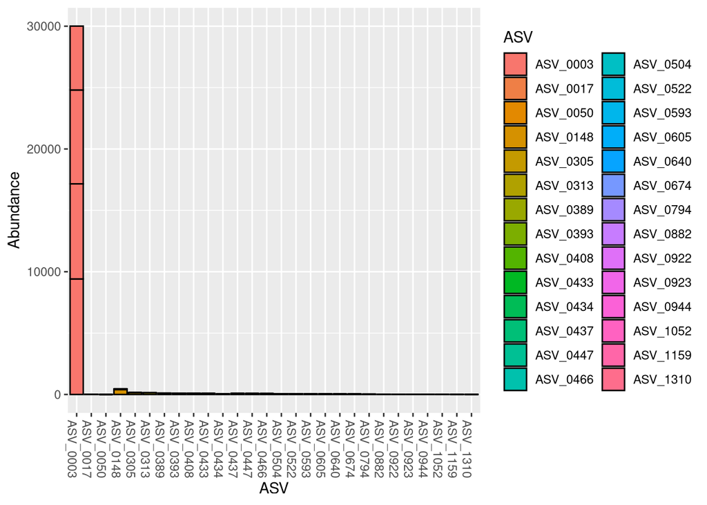

```r
# Make a phyloseq object with only the negative controls
neg_control_samples <- c("WaterControl", "022um-Control", "3um-Control", "DNA-Ext-Control")

# Create physeq object with only negative controls
neg_control_physeq <-
  noChlorosMitos_physeq %>%
  subset_samples(., names %in% neg_control_samples) %>%
  # rm ASVs with 0 counts
  prune_taxa(taxa_sums(.) > 0, .)

# Take a look at the ASV abundances in neg controls
neg_control_physeq %>%
  plot_bar(., "ASV", fill = "ASV")
```

```r
# What's the abundance of these neg controls in real samples?
# Create vector of ASVs
neg_controlASVs_vec <-
  neg_control_physeq %>%
  tax_table() %>%
  data.frame() %>%
  dplyr::select(ASV) %>%
  as.vector()

# use vector to subset from larger dataset, creating a new phyloseq object
neg_controlASV_physeq <-
  noChlorosMitos_physeq %>%
  subset_taxa(., ASV %in% neg_controlASVs_vec$ASV)

# Take a look
neg_controlASV_physeq
```

```
## phyloseq-class experiment-level object
## otu_table()   OTU Table:         [ 28 taxa and 95 samples ]
## sample_data() Sample Data:       [ 95 samples by 43 sample variables ]
## tax_table()   Taxonomy Table:    [ 28 taxa by 9 taxonomic ranks ]
```

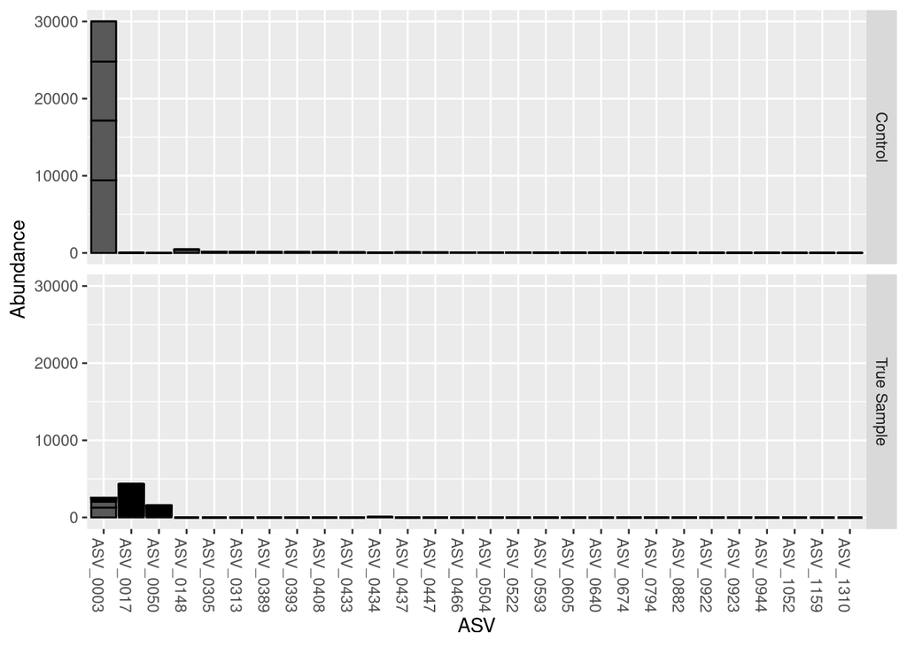

```r
#Plot abundances of ASVs in samples vs controls
neg_controlASV_physeq %>%
  plot_bar(., "ASV", facet_grid = Sample_or_Control~.)
```

```r
# Create a new vector with all ASVs except ASV_0017 and ASV_0050
neg_controlASVs_toRemove <- dplyr::setdiff(neg_controlASVs_vec$ASV, c("ASV_0017", "ASV_0050"))

# Make new phyloseq object with neg control ASVs removed
noChlorosMitosNegControls_physeq <-
  noChlorosMitos_physeq %>%
  # rm ASVs
  subset_taxa(., !(ASV %in% neg_controlASVs_toRemove)) %>%
  # rm samples
  subset_samples(., !(names %in% neg_control_samples))

neg_controlASVs_toRemove
```

```
##  [1] "ASV_0003" "ASV_0148" "ASV_0305" "ASV_0313" "ASV_0389" "ASV_0393"
##  [7] "ASV_0408" "ASV_0433" "ASV_0434" "ASV_0437" "ASV_0447" "ASV_0466"
## [13] "ASV_0504" "ASV_0522" "ASV_0593" "ASV_0605" "ASV_0640" "ASV_0674"
## [19] "ASV_0794" "ASV_0882" "ASV_0922" "ASV_0923" "ASV_0944" "ASV_1052"
## [25] "ASV_1159" "ASV_1310"
```